# MP3_P2

```python
from google.colab import drive
drive.mount("/content/gdrive")
```

```python
import os
HOME_DIR = os.getcwd()
PWD = os.path.join(HOME_DIR, 'gdrive', 'MyDrive', 'Colab Notebooks', 'CS498', 'assignment3_part2')
print(PWD)
os.chdir(PWD)
```

```
/content/gdrive/MyDrive/Colab Notebooks/CS498/assignment3_part2
```

```python
import os
import random

import cv2
import numpy as np

import torch
from torch.utils.data import DataLoader
from torchvision import models

from src.resnet_yolo import resnet50
# from yolo_loss import YoloLoss
from src.dataset import VocDetectorDataset
from src.eval_voc import evaluate
from src.predict import predict_image
from src.config import VOC_CLASSES, COLORS
from kaggle_submission import output_submission_csv

import matplotlib.pyplot as plt
import collections

%matplotlib inline
%load_ext autoreload
%autoreload 1

%aimport yolo_loss
```

```python
# !chmod u+rwx download_data.sh
# !./download_data.sh
# !wget http://host.robots.ox.ac.uk/pascal/VOC/voc2007/VOCtrainval_06-Nov-2007.tar
# !wget http://host.robots.ox.ac.uk/pascal/VOC/voc2007/VOCtest_06-Nov-2007.tar
```

```python
#!cat download_data.sh
```

```python
import shutil

# This one works but takes infinite time!
# shutil.copytree("data", "/content/data")

###### shutil.rmtree("/content/data/VOCdevkit_2007")

os.makedirs("/content/data", exist_ok = True)

if os.listdir("/content/data"):
  pass
else:
  shutil.copyfile("VOCtrainval_06-Nov-2007.tar", "/content/data/VOCtrainval_06-Nov-2007.tar")
  !tar -xf "/content/data/VOCtrainval_06-Nov-2007.tar" -C "/content/data/"
  shutil.move("/content/data/VOCdevkit", "/content/data/VOCdevkit_2007")

  shutil.copyfile("VOCtest_06-Nov-2007.tar", "/content/data/VOCtest_06-Nov-2007.tar")
  !tar -xf "/content/data/VOCtest_06-Nov-2007.tar" -C "/content/data/"
  shutil.move("/content/data/VOCdevkit/VOC2007", "/content/data/VOCdevkit_2007/VOC2007test")

os.listdir("/content/data")
```

```
['VOCdevkit_2007',
 'VOCtrainval_06-Nov-2007.tar',
 'VOCdevkit',
 'VOCtest_06-Nov-2007.tar']
```

## Initialization

```python
device = torch.device("cuda:0" if torch.cuda.is_available() else "cpu")
device
```

```
device(type='cuda', index=0)
```

```python
# YOLO network hyperparameters
B = 2  # number of bounding box predictions per cell
S = 14  # width/height of network output grid (larger than 7x7 from paper since we use a different network)
```

To implement Yolo we will rely on a pretrained classifier as the backbone for our detection network. PyTorch offers a variety of models which are pretrained on ImageNet in the [`torchvision.models`](https://pytorch.org/docs/stable/torchvision/models.html) package. In particular, we will use the ResNet50 architecture as a base for our detector. This is different from the base architecture in the Yolo paper and also results in a different output grid size (14x14 instead of 7x7).

Models are typically pretrained on ImageNet since the dataset is very large (> 1 million images) and widely used. The pretrained model provides a very useful weight initialization for our detector, so that the network is able to learn quickly and effectively.

```python
load_network_path = None #'checkpoints/best_detector.pth'
pretrained = True

# use to load a previously trained network
if load_network_path is not None:
    print('Loading saved network from {}'.format(load_network_path))
    net = resnet50().to(device)
    net.load_state_dict(torch.load(load_network_path))
else:
    print('Load pre-trained model')
    net = resnet50(pretrained=pretrained).to(device)
```

```
Load pre-trained model
```

```
Downloading: "https://download.pytorch.org/models/resnet50-19c8e357.pth" to /root/.cache/torch/hub/checkpoints/resnet50-19c8e357.pth
```

```python
learning_rate = 0.001
num_epochs = 50
batch_size = 24

# Yolo loss component coefficients (as given in Yolo v1 paper)
lambda_coord = 5
lambda_noobj = 0.5
```

## Reading Pascal Data

Since Pascal is a small dataset (5000 in train+val) we have combined the train and val splits to train our detector. This is not typically a good practice, but we will make an exception in this case to be able to get reasonable detection results with a comparatively small object detection dataset.

The train dataset loader also using a variety of data augmentation techniques including random shift, scaling, crop, and flips. Data augmentation is slightly more complicated for detection datasets since the bounding box annotations must be kept consistent throughout the transformations.

Since the output of the detector network we train is an SxSx(B*5+C), we use an encoder to convert the original bounding box coordinates into relative grid bounding box coordinates corresponding to the expected output. We also use a decoder which allows us to convert the opposite direction into image coordinate bounding boxes.

```python
file_root_train = '/content/data/VOCdevkit_2007/VOC2007/JPEGImages/'
# can't seem to get it on drive
annotation_file_train = os.path.join(PWD, 'data', 'voc2007.txt')

train_dataset = VocDetectorDataset(root_img_dir=file_root_train,dataset_file=annotation_file_train,train=True, S=S)
train_loader = DataLoader(train_dataset,batch_size=batch_size,shuffle=True,num_workers=2)
print('Loaded %d train images' % len(train_dataset))
```

```
Initializing dataset
Loaded 5011 train images
```

```python
file_root_test = '/content/data/VOCdevkit_2007/VOC2007test/JPEGImages/'

# can't seem to get it on drive
annotation_file_test = os.path.join(PWD, 'data', 'voc2007test.txt')
# annotation_file_test = '/content/data/voc2007test.txt'

test_dataset = VocDetectorDataset(root_img_dir=file_root_test,dataset_file=annotation_file_test,train=False, S=S)
test_loader = DataLoader(test_dataset,batch_size=batch_size,shuffle=False,num_workers=2)
print('Loaded %d test images' % len(test_dataset))
```

```
Initializing dataset
Loaded 4950 test images
```

```python
data = train_dataset[0]
```

## Set up training tools

```python
from yolo_loss import YoloLoss

criterion = YoloLoss(S, B, lambda_coord, lambda_noobj)
optimizer = torch.optim.SGD(net.parameters(), lr=learning_rate, momentum=0.9, weight_decay=5e-4)
```

## Train detector

```python
best_test_loss = np.inf
learning_rate = 1e-3
for epoch in range(num_epochs):
    net.train()

    # Update learning rate late in training
    if epoch == 30 or epoch == 40:
        learning_rate /= 10.0

    for param_group in optimizer.param_groups:
        param_group['lr'] = learning_rate

    print('\n\nStarting epoch %d / %d' % (epoch + 1, num_epochs))
    print('Learning Rate for this epoch: {}'.format(learning_rate))

    total_loss = collections.defaultdict(int)

    for i, data in enumerate(train_loader):
        data = (item.to(device) for item in data)
        images, target_boxes, target_cls, has_object_map = data
        pred = net(images)
        loss_dict = criterion(pred, target_boxes, target_cls, has_object_map)
        for key in loss_dict:
            total_loss[key] += loss_dict[key].item()

        optimizer.zero_grad()
        loss_dict['total_loss'].backward()
        optimizer.step()

        if (i+1) % 50 == 0:
            outstring = 'Epoch [%d/%d], Iter [%d/%d], Loss: ' % ((epoch+1, num_epochs, i+1, len(train_loader)))
            outstring += ', '.join( "%s=%.3f" % (key[:-5], val / (i+1)) for key, val in total_loss.items() )
            print(outstring)

    # evaluate the network on the test data
    if (epoch + 1) % 5 == 0:
        test_aps = evaluate(net, test_dataset_file=annotation_file_test, img_root=file_root_test)
        print(epoch, test_aps)
    with torch.no_grad():
        test_loss = 0.0
        net.eval()
        for i, data in enumerate(test_loader):
            data = (item.to(device) for item in data)
            images, target_boxes, target_cls, has_object_map = data

            pred = net(images)
            loss_dict = criterion(pred, target_boxes, target_cls, has_object_map)
            test_loss += loss_dict['total_loss'].item()
        test_loss /= len(test_loader)

    if best_test_loss > test_loss:
        best_test_loss = test_loss
        print('Updating best test loss: %.5f' % best_test_loss)
        torch.save(net.state_dict(),'checkpoints/best_detector.pth')

    if (epoch+1) in [5, 10, 20, 30, 40]:
        torch.save(net.state_dict(),'checkpoints/detector_epoch_%d.pth' % (epoch+1))

    torch.save(net.state_dict(),'checkpoints/detector.pth')
```

```
Starting epoch 1 / 50
Learning Rate for this epoch: 0.001
Epoch [1/50], Iter [50/209], Loss: total=23.559, reg=3.732, containing_obj=0.326, no_obj=12.496, cls=7.005
Epoch [1/50], Iter [100/209], Loss: total=15.702, reg=3.289, containing_obj=0.457, no_obj=6.472, cls=5.483
Epoch [1/50], Iter [150/209], Loss: total=12.453, reg=2.943, containing_obj=0.521, no_obj=4.419, cls=4.571
Epoch [1/50], Iter [200/209], Loss: total=10.736, reg=2.747, containing_obj=0.564, no_obj=3.376, cls=4.050
Updating best test loss: 5.30552


Starting epoch 2 / 50
Learning Rate for this epoch: 0.001
Epoch [2/50], Iter [50/209], Loss: total=5.367, reg=2.152, containing_obj=0.760, no_obj=0.200, cls=2.254
Epoch [2/50], Iter [100/209], Loss: total=5.095, reg=2.053, containing_obj=0.765, no_obj=0.187, cls=2.089
Epoch [2/50], Iter [150/209], Loss: total=4.990, reg=2.043, containing_obj=0.770, no_obj=0.177, cls=1.999
Epoch [2/50], Iter [200/209], Loss: total=4.891, reg=2.016, containing_obj=0.776, no_obj=0.168, cls=1.930
Updating best test loss: 4.55274


Starting epoch 3 / 50
Learning Rate for this epoch: 0.001
Epoch [3/50], Iter [50/209], Loss: total=4.300, reg=1.841, containing_obj=0.796, no_obj=0.129, cls=1.534
Epoch [3/50], Iter [100/209], Loss: total=4.332, reg=1.869, containing_obj=0.807, no_obj=0.125, cls=1.531
Epoch [3/50], Iter [150/209], Loss: total=4.317, reg=1.858, containing_obj=0.824, no_obj=0.121, cls=1.514
Epoch [3/50], Iter [200/209], Loss: total=4.298, reg=1.864, containing_obj=0.828, no_obj=0.119, cls=1.487
Updating best test loss: 4.20904


Starting epoch 4 / 50
Learning Rate for this epoch: 0.001
Epoch [4/50], Iter [50/209], Loss: total=4.090, reg=1.828, containing_obj=0.860, no_obj=0.106, cls=1.296
Epoch [4/50], Iter [100/209], Loss: total=4.057, reg=1.806, containing_obj=0.854, no_obj=0.105, cls=1.292
Epoch [4/50], Iter [150/209], Loss: total=4.012, reg=1.802, containing_obj=0.847, no_obj=0.104, cls=1.258
Epoch [4/50], Iter [200/209], Loss: total=3.989, reg=1.798, containing_obj=0.843, no_obj=0.104, cls=1.243
Updating best test loss: 3.92307


Starting epoch 5 / 50
Learning Rate for this epoch: 0.001
Epoch [5/50], Iter [50/209], Loss: total=3.756, reg=1.726, containing_obj=0.842, no_obj=0.103, cls=1.085
Epoch [5/50], Iter [100/209], Loss: total=3.752, reg=1.740, containing_obj=0.846, no_obj=0.103, cls=1.063
Epoch [5/50], Iter [150/209], Loss: total=3.715, reg=1.724, containing_obj=0.846, no_obj=0.104, cls=1.041
Epoch [5/50], Iter [200/209], Loss: total=3.680, reg=1.718, containing_obj=0.839, no_obj=0.106, cls=1.017
---Evaluate model on test samples---
```

```
---class aeroplane ap 0.07983513831067358---
---class bicycle ap 0.14356307337531068---
---class bird ap 0.07812025413550663---
---class boat ap 0.007971662793072263---
---class bottle ap 0.02693928131111303---
---class bus ap 0.0--- (no predictions for this class)
---class car ap 0.12463924725837798---
---class cat ap 0.017404383326171037---
---class chair ap 0.06417883369080232---
---class cow ap 0.004098360655737705---
---class diningtable ap 0.0--- (no predictions for this class)
---class dog ap 0.04686018857797998---
---class horse ap 0.15568090933568307---
---class motorbike ap 0.17035303091811024---
---class person ap 0.16321401962031537---
---class pottedplant ap 0.010287414965986395---
---class sheep ap 0.02571609111160511---
---class sofa ap 0.004201680672268907---
---class train ap 0.0--- (no predictions for this class)
---class tvmonitor ap 0.09980355670647927---
---map 0.061143356338259666---
4 [0.07983513831067358, 0.14356307337531068, 0.07812025413550663, 0.007971662793072263, 0.02693928131111303, 0.0, 0.12463924725837798, 0.017404383326171037, 0.06417883369080232, 0.004098360655737705, 0.0, 0.04686018857797998, 0.15568090933568307, 0.17035303091811024, 0.16321401962031537, 0.010287414…
Updating best test loss: 3.74919


Starting epoch 6 / 50
Learning Rate for this epoch: 0.001
Epoch [6/50], Iter [50/209], Loss: total=3.518, reg=1.674, containing_obj=0.823, no_obj=0.114, cls=0.907
Epoch [6/50], Iter [100/209], Loss: total=3.556, reg=1.709, containing_obj=0.833, no_obj=0.114, cls=0.900
Epoch [6/50], Iter [150/209], Loss: total=3.542, reg=1.696, containing_obj=0.832, no_obj=0.114, cls=0.899
Epoch [6/50], Iter [200/209], Loss: total=3.535, reg=1.686, containing_obj=0.832, no_obj=0.115, cls=0.903
Updating best test loss: 3.60457


Starting epoch 7 / 50
Learning Rate for this epoch: 0.001
Epoch [7/50], Iter [50/209], Loss: total=3.438, reg=1.660, containing_obj=0.844, no_obj=0.118, cls=0.816
Epoch [7/50], Iter [100/209], Loss: total=3.403, reg=1.643, containing_obj=0.831, no_obj=0.119, cls=0.810
Epoch [7/50], Iter [150/209], Loss: total=3.411, reg=1.647, containing_obj=0.836, no_obj=0.119, cls=0.810
Epoch [7/50], Iter [200/209], Loss: total=3.359, reg=1.627, containing_obj=0.829, no_obj=0.120, cls=0.783
```

[output cut: 13 more lines]

```
Learning Rate for this epoch: 0.001
Epoch [9/50], Iter [50/209], Loss: total=3.111, reg=1.518, containing_obj=0.821, no_obj=0.126, cls=0.647
Epoch [9/50], Iter [100/209], Loss: total=3.121, reg=1.537, containing_obj=0.823, no_obj=0.126, cls=0.636
Epoch [9/50], Iter [150/209], Loss: total=3.079, reg=1.512, containing_obj=0.811, no_obj=0.126, cls=0.630
Epoch [9/50], Iter [200/209], Loss: total=3.054, reg=1.497, containing_obj=0.807, no_obj=0.127, cls=0.624
Updating best test loss: 3.34135


Starting epoch 10 / 50
Learning Rate for this epoch: 0.001
Epoch [10/50], Iter [50/209], Loss: total=3.089, reg=1.546, containing_obj=0.829, no_obj=0.130, cls=0.585
Epoch [10/50], Iter [100/209], Loss: total=3.019, reg=1.502, containing_obj=0.820, no_obj=0.130, cls=0.566
Epoch [10/50], Iter [150/209], Loss: total=2.990, reg=1.480, containing_obj=0.814, no_obj=0.130, cls=0.566
Epoch [10/50], Iter [200/209], Loss: total=3.014, reg=1.490, containing_obj=0.818, no_obj=0.131, cls=0.575
---Evaluate model on test samples---
```

```
---class aeroplane ap 0.31354312219089975---
---class bicycle ap 0.26540301746591766---
---class bird ap 0.13504441312418825---
---class boat ap 0.06499324425359435---
---class bottle ap 0.049691189047948094---
---class bus ap 0.29319559646617643---
---class car ap 0.3656605512536776---
---class cat ap 0.4032838675745606---
---class chair ap 0.1308889946548818---
---class cow ap 0.2591017703247489---
---class diningtable ap 0.014563106796116505---
---class dog ap 0.35273064845002056---
---class horse ap 0.48869289599073384---
---class motorbike ap 0.375269881719844---
---class person ap 0.3235753367541447---
---class pottedplant ap 0.03514679449631096---
---class sheep ap 0.22160206067074772---
---class sofa ap 0.24101893747127853---
---class train ap 0.4319674361056627---
---class tvmonitor ap 0.2895473422111954---
---map 0.2527460103511324---
9 [0.31354312219089975, 0.26540301746591766, 0.13504441312418825, 0.06499324425359435, 0.049691189047948094, 0.29319559646617643, 0.3656605512536776, 0.4032838675745606, 0.1308889946548818, 0.2591017703247489, 0.014563106796116505, 0.35273064845002056, 0.48869289599073384, 0.375269881719844, 0.32357…
Updating best test loss: 3.26378


Starting epoch 11 / 50
Learning Rate for this epoch: 0.001
Epoch [11/50], Iter [50/209], Loss: total=2.877, reg=1.435, containing_obj=0.794, no_obj=0.135, cls=0.513
Epoch [11/50], Iter [100/209], Loss: total=2.927, reg=1.458, containing_obj=0.801, no_obj=0.134, cls=0.534
Epoch [11/50], Iter [150/209], Loss: total=2.937, reg=1.464, containing_obj=0.801, no_obj=0.134, cls=0.538
Epoch [11/50], Iter [200/209], Loss: total=2.954, reg=1.473, containing_obj=0.806, no_obj=0.136, cls=0.540
Updating best test loss: 3.21774


Starting epoch 12 / 50
Learning Rate for this epoch: 0.001
Epoch [12/50], Iter [50/209], Loss: total=2.899, reg=1.448, containing_obj=0.797, no_obj=0.141, cls=0.513
Epoch [12/50], Iter [100/209], Loss: total=2.922, reg=1.468, containing_obj=0.799, no_obj=0.145, cls=0.509
Epoch [12/50], Iter [150/209], Loss: total=2.865, reg=1.429, containing_obj=0.785, no_obj=0.148, cls=0.503
Epoch [12/50], Iter [200/209], Loss: total=2.831, reg=1.410, containing_obj=0.779, no_obj=0.148, cls=0.494
```

[output cut: 13 more lines]

```
Learning Rate for this epoch: 0.001
Epoch [14/50], Iter [50/209], Loss: total=2.745, reg=1.394, containing_obj=0.769, no_obj=0.160, cls=0.423
Epoch [14/50], Iter [100/209], Loss: total=2.665, reg=1.346, containing_obj=0.739, no_obj=0.163, cls=0.417
Epoch [14/50], Iter [150/209], Loss: total=2.660, reg=1.334, containing_obj=0.736, no_obj=0.163, cls=0.427
Epoch [14/50], Iter [200/209], Loss: total=2.672, reg=1.334, containing_obj=0.742, no_obj=0.163, cls=0.433
Updating best test loss: 3.10795


Starting epoch 15 / 50
Learning Rate for this epoch: 0.001
Epoch [15/50], Iter [50/209], Loss: total=2.492, reg=1.242, containing_obj=0.709, no_obj=0.170, cls=0.372
Epoch [15/50], Iter [100/209], Loss: total=2.565, reg=1.270, containing_obj=0.728, no_obj=0.166, cls=0.401
Epoch [15/50], Iter [150/209], Loss: total=2.610, reg=1.306, containing_obj=0.734, no_obj=0.166, cls=0.404
Epoch [15/50], Iter [200/209], Loss: total=2.647, reg=1.324, containing_obj=0.740, no_obj=0.168, cls=0.415
---Evaluate model on test samples---
```

```
---class aeroplane ap 0.39483597961735234---
---class bicycle ap 0.3996837599830793---
---class bird ap 0.2992999364555745---
---class boat ap 0.14889983180141378---
---class bottle ap 0.10965911641947415---
---class bus ap 0.3495846913107422---
---class car ap 0.5573960829094418---
---class cat ap 0.5780839059318427---
---class chair ap 0.20432646427122464---
---class cow ap 0.3734850610564576---
---class diningtable ap 0.1541907627589885---
---class dog ap 0.46424916043544356---
---class horse ap 0.5477487787416769---
---class motorbike ap 0.4370939794211116---
---class person ap 0.40325517073793715---
---class pottedplant ap 0.10425497923501822---
---class sheep ap 0.31799023431854384---
---class sofa ap 0.30543352862762096---
---class train ap 0.46765487772012027---
---class tvmonitor ap 0.3135521736610992---
---map 0.34653392377070813---
14 [0.39483597961735234, 0.3996837599830793, 0.2992999364555745, 0.14889983180141378, 0.10965911641947415, 0.3495846913107422, 0.5573960829094418, 0.5780839059318427, 0.20432646427122464, 0.3734850610564576, 0.1541907627589885, 0.46424916043544356, 0.5477487787416769, 0.4370939794211116, 0.403255170…
Updating best test loss: 3.01616


Starting epoch 16 / 50
Learning Rate for this epoch: 0.001
Epoch [16/50], Iter [50/209], Loss: total=2.548, reg=1.282, containing_obj=0.729, no_obj=0.178, cls=0.359
Epoch [16/50], Iter [100/209], Loss: total=2.537, reg=1.273, containing_obj=0.717, no_obj=0.177, cls=0.370
Epoch [16/50], Iter [150/209], Loss: total=2.577, reg=1.290, containing_obj=0.724, no_obj=0.175, cls=0.387
Epoch [16/50], Iter [200/209], Loss: total=2.595, reg=1.301, containing_obj=0.725, no_obj=0.175, cls=0.394


Starting epoch 17 / 50
Learning Rate for this epoch: 0.001
Epoch [17/50], Iter [50/209], Loss: total=2.500, reg=1.256, containing_obj=0.695, no_obj=0.175, cls=0.374
Epoch [17/50], Iter [100/209], Loss: total=2.526, reg=1.264, containing_obj=0.712, no_obj=0.175, cls=0.375
Epoch [17/50], Iter [150/209], Loss: total=2.534, reg=1.272, containing_obj=0.714, no_obj=0.175, cls=0.373
Epoch [17/50], Iter [200/209], Loss: total=2.517, reg=1.255, containing_obj=0.710, no_obj=0.175, cls=0.376
Updating best test loss: 2.96260
```

[output cut: 11 more lines]

```
Learning Rate for this epoch: 0.001
Epoch [19/50], Iter [50/209], Loss: total=2.454, reg=1.200, containing_obj=0.737, no_obj=0.179, cls=0.337
Epoch [19/50], Iter [100/209], Loss: total=2.467, reg=1.229, containing_obj=0.725, no_obj=0.175, cls=0.338
Epoch [19/50], Iter [150/209], Loss: total=2.427, reg=1.206, containing_obj=0.705, no_obj=0.179, cls=0.337
Epoch [19/50], Iter [200/209], Loss: total=2.444, reg=1.217, containing_obj=0.702, no_obj=0.179, cls=0.346
Updating best test loss: 2.88618


Starting epoch 20 / 50
Learning Rate for this epoch: 0.001
Epoch [20/50], Iter [50/209], Loss: total=2.391, reg=1.188, containing_obj=0.692, no_obj=0.179, cls=0.332
Epoch [20/50], Iter [100/209], Loss: total=2.394, reg=1.197, containing_obj=0.688, no_obj=0.184, cls=0.325
Epoch [20/50], Iter [150/209], Loss: total=2.398, reg=1.197, containing_obj=0.698, no_obj=0.182, cls=0.320
Epoch [20/50], Iter [200/209], Loss: total=2.389, reg=1.189, containing_obj=0.690, no_obj=0.183, cls=0.326
---Evaluate model on test samples---
```

```
---class aeroplane ap 0.4240971072634972---
---class bicycle ap 0.49751519878111944---
---class bird ap 0.3587454006747258---
---class boat ap 0.21503207585089437---
---class bottle ap 0.18655102454235012---
---class bus ap 0.5096917535872358---
---class car ap 0.5977803463877092---
---class cat ap 0.676991364681634---
---class chair ap 0.17048942629896174---
---class cow ap 0.3663374107919373---
---class diningtable ap 0.16335083435556103---
---class dog ap 0.5773989425968528---
---class horse ap 0.5826756086007873---
---class motorbike ap 0.4603415299483671---
---class person ap 0.4791733022505239---
---class pottedplant ap 0.1463473105501863---
---class sheep ap 0.3232513018754287---
---class sofa ap 0.34728559338161286---
---class train ap 0.6071944166158025---
---class tvmonitor ap 0.3969769703631614---
---map 0.40436134596991735---
19 [0.4240971072634972, 0.49751519878111944, 0.3587454006747258, 0.21503207585089437, 0.18655102454235012, 0.5096917535872358, 0.5977803463877092, 0.676991364681634, 0.17048942629896174, 0.3663374107919373, 0.16335083435556103, 0.5773989425968528, 0.5826756086007873, 0.4603415299483671, 0.4791733022…


Starting epoch 21 / 50
Learning Rate for this epoch: 0.001
Epoch [21/50], Iter [50/209], Loss: total=2.308, reg=1.129, containing_obj=0.689, no_obj=0.181, cls=0.308
Epoch [21/50], Iter [100/209], Loss: total=2.300, reg=1.139, containing_obj=0.680, no_obj=0.182, cls=0.300
Epoch [21/50], Iter [150/209], Loss: total=2.302, reg=1.137, containing_obj=0.680, no_obj=0.182, cls=0.302
Epoch [21/50], Iter [200/209], Loss: total=2.330, reg=1.151, containing_obj=0.686, no_obj=0.184, cls=0.309


Starting epoch 22 / 50
Learning Rate for this epoch: 0.001
Epoch [22/50], Iter [50/209], Loss: total=2.368, reg=1.166, containing_obj=0.695, no_obj=0.182, cls=0.324
Epoch [22/50], Iter [100/209], Loss: total=2.318, reg=1.150, containing_obj=0.675, no_obj=0.184, cls=0.309
Epoch [22/50], Iter [150/209], Loss: total=2.318, reg=1.157, containing_obj=0.673, no_obj=0.186, cls=0.302
Epoch [22/50], Iter [200/209], Loss: total=2.327, reg=1.162, containing_obj=0.675, no_obj=0.187, cls=0.304


```

[output cut: 9 more lines]

```
Starting epoch 24 / 50
Learning Rate for this epoch: 0.001
Epoch [24/50], Iter [50/209], Loss: total=2.214, reg=1.094, containing_obj=0.663, no_obj=0.185, cls=0.273
Epoch [24/50], Iter [100/209], Loss: total=2.225, reg=1.100, containing_obj=0.660, no_obj=0.186, cls=0.279
Epoch [24/50], Iter [150/209], Loss: total=2.225, reg=1.093, containing_obj=0.666, no_obj=0.185, cls=0.281
Epoch [24/50], Iter [200/209], Loss: total=2.245, reg=1.112, containing_obj=0.669, no_obj=0.185, cls=0.280


Starting epoch 25 / 50
Learning Rate for this epoch: 0.001
Epoch [25/50], Iter [50/209], Loss: total=2.134, reg=1.037, containing_obj=0.654, no_obj=0.195, cls=0.247
Epoch [25/50], Iter [100/209], Loss: total=2.178, reg=1.067, containing_obj=0.658, no_obj=0.195, cls=0.258
Epoch [25/50], Iter [150/209], Loss: total=2.182, reg=1.079, containing_obj=0.655, no_obj=0.192, cls=0.256
Epoch [25/50], Iter [200/209], Loss: total=2.192, reg=1.080, containing_obj=0.660, no_obj=0.191, cls=0.261
---Evaluate model on test samples---
```

```
---class aeroplane ap 0.44511672952244613---
---class bicycle ap 0.4121336086620847---
---class bird ap 0.35940543111523715---
---class boat ap 0.20330705895322698---
---class bottle ap 0.15257700025206758---
---class bus ap 0.5188863640013355---
---class car ap 0.6124662372614691---
---class cat ap 0.6558660449971601---
---class chair ap 0.24826549828119454---
---class cow ap 0.4163295082810502---
---class diningtable ap 0.2109892363580189---
---class dog ap 0.5619902103059569---
---class horse ap 0.579478383807076---
---class motorbike ap 0.49217664269045514---
---class person ap 0.4944617150787423---
---class pottedplant ap 0.14350620224826882---
---class sheep ap 0.36043334237324653---
---class sofa ap 0.36795206184846263---
---class train ap 0.5642235082057184---
---class tvmonitor ap 0.4708803488735756---
---map 0.41352225665583964---
24 [0.44511672952244613, 0.4121336086620847, 0.35940543111523715, 0.20330705895322698, 0.15257700025206758, 0.5188863640013355, 0.6124662372614691, 0.6558660449971601, 0.24826549828119454, 0.4163295082810502, 0.2109892363580189, 0.5619902103059569, 0.579478383807076, 0.49217664269045514, 0.494461715…


Starting epoch 26 / 50
Learning Rate for this epoch: 0.001
Epoch [26/50], Iter [50/209], Loss: total=2.207, reg=1.101, containing_obj=0.643, no_obj=0.190, cls=0.273
Epoch [26/50], Iter [100/209], Loss: total=2.184, reg=1.095, containing_obj=0.636, no_obj=0.194, cls=0.260
Epoch [26/50], Iter [150/209], Loss: total=2.180, reg=1.084, containing_obj=0.642, no_obj=0.191, cls=0.264
Epoch [26/50], Iter [200/209], Loss: total=2.180, reg=1.085, containing_obj=0.644, no_obj=0.191, cls=0.261
Updating best test loss: 2.81966


Starting epoch 27 / 50
Learning Rate for this epoch: 0.001
Epoch [27/50], Iter [50/209], Loss: total=2.122, reg=1.034, containing_obj=0.660, no_obj=0.192, cls=0.235
Epoch [27/50], Iter [100/209], Loss: total=2.163, reg=1.051, containing_obj=0.675, no_obj=0.194, cls=0.243
Epoch [27/50], Iter [150/209], Loss: total=2.142, reg=1.045, containing_obj=0.653, no_obj=0.197, cls=0.248
Epoch [27/50], Iter [200/209], Loss: total=2.145, reg=1.052, containing_obj=0.652, no_obj=0.195, cls=0.246
Updating best test loss: 2.81592
```

[output cut: 11 more lines]

```
Learning Rate for this epoch: 0.001
Epoch [29/50], Iter [50/209], Loss: total=2.005, reg=0.992, containing_obj=0.623, no_obj=0.184, cls=0.205
Epoch [29/50], Iter [100/209], Loss: total=2.078, reg=1.031, containing_obj=0.630, no_obj=0.191, cls=0.226
Epoch [29/50], Iter [150/209], Loss: total=2.078, reg=1.025, containing_obj=0.626, no_obj=0.193, cls=0.234
Epoch [29/50], Iter [200/209], Loss: total=2.094, reg=1.035, containing_obj=0.629, no_obj=0.195, cls=0.236
Updating best test loss: 2.80187


Starting epoch 30 / 50
Learning Rate for this epoch: 0.001
Epoch [30/50], Iter [50/209], Loss: total=2.066, reg=1.011, containing_obj=0.632, no_obj=0.193, cls=0.231
Epoch [30/50], Iter [100/209], Loss: total=2.050, reg=1.010, containing_obj=0.624, no_obj=0.194, cls=0.223
Epoch [30/50], Iter [150/209], Loss: total=2.044, reg=1.008, containing_obj=0.619, no_obj=0.195, cls=0.223
Epoch [30/50], Iter [200/209], Loss: total=2.038, reg=1.004, containing_obj=0.617, no_obj=0.195, cls=0.222
---Evaluate model on test samples---
```

```
---class aeroplane ap 0.3982221495295063---
---class bicycle ap 0.5211872415972582---
---class bird ap 0.44461334982002076---
---class boat ap 0.21234230072078492---
---class bottle ap 0.15251888158181678---
---class bus ap 0.516078071604608---
---class car ap 0.635170701118017---
---class cat ap 0.6691726697851588---
---class chair ap 0.275289145717892---
---class cow ap 0.41350309200311536---
---class diningtable ap 0.245742467425447---
---class dog ap 0.5288337695974621---
---class horse ap 0.6403730032326186---
---class motorbike ap 0.4755194033060918---
---class person ap 0.5135184211144979---
---class pottedplant ap 0.14592168274592826---
---class sheep ap 0.3976018461686986---
---class sofa ap 0.42782133807095435---
---class train ap 0.6200238003690247---
---class tvmonitor ap 0.47250735792189147---
---map 0.43529803467153966---
29 [0.3982221495295063, 0.5211872415972582, 0.44461334982002076, 0.21234230072078492, 0.15251888158181678, 0.516078071604608, 0.635170701118017, 0.6691726697851588, 0.275289145717892, 0.41350309200311536, 0.245742467425447, 0.5288337695974621, 0.6403730032326186, 0.4755194033060918, 0.51351842111449…


Starting epoch 31 / 50
Learning Rate for this epoch: 0.0001
Epoch [31/50], Iter [50/209], Loss: total=1.946, reg=0.940, containing_obj=0.587, no_obj=0.200, cls=0.218
Epoch [31/50], Iter [100/209], Loss: total=1.982, reg=0.957, containing_obj=0.610, no_obj=0.199, cls=0.215
Epoch [31/50], Iter [150/209], Loss: total=1.983, reg=0.958, containing_obj=0.612, no_obj=0.200, cls=0.213
Epoch [31/50], Iter [200/209], Loss: total=1.980, reg=0.960, containing_obj=0.614, no_obj=0.199, cls=0.208
Updating best test loss: 2.71246


Starting epoch 32 / 50
Learning Rate for this epoch: 0.0001
Epoch [32/50], Iter [50/209], Loss: total=1.928, reg=0.928, containing_obj=0.619, no_obj=0.200, cls=0.180
Epoch [32/50], Iter [100/209], Loss: total=1.932, reg=0.937, containing_obj=0.612, no_obj=0.196, cls=0.187
Epoch [32/50], Iter [150/209], Loss: total=1.907, reg=0.920, containing_obj=0.602, no_obj=0.200, cls=0.186
Epoch [32/50], Iter [200/209], Loss: total=1.922, reg=0.934, containing_obj=0.604, no_obj=0.199, cls=0.185
Updating best test loss: 2.69871
```

[output cut: 11 more lines]

```
Starting epoch 34 / 50
Learning Rate for this epoch: 0.0001
Epoch [34/50], Iter [50/209], Loss: total=1.968, reg=0.955, containing_obj=0.620, no_obj=0.199, cls=0.194
Epoch [34/50], Iter [100/209], Loss: total=1.923, reg=0.928, containing_obj=0.612, no_obj=0.197, cls=0.185
Epoch [34/50], Iter [150/209], Loss: total=1.888, reg=0.910, containing_obj=0.594, no_obj=0.201, cls=0.183
Epoch [34/50], Iter [200/209], Loss: total=1.887, reg=0.907, containing_obj=0.595, no_obj=0.202, cls=0.183


Starting epoch 35 / 50
Learning Rate for this epoch: 0.0001
Epoch [35/50], Iter [50/209], Loss: total=1.865, reg=0.895, containing_obj=0.590, no_obj=0.204, cls=0.175
Epoch [35/50], Iter [100/209], Loss: total=1.871, reg=0.905, containing_obj=0.589, no_obj=0.203, cls=0.173
Epoch [35/50], Iter [150/209], Loss: total=1.866, reg=0.908, containing_obj=0.585, no_obj=0.202, cls=0.170
Epoch [35/50], Iter [200/209], Loss: total=1.856, reg=0.901, containing_obj=0.584, no_obj=0.203, cls=0.168
---Evaluate model on test samples---
```

```
---class aeroplane ap 0.5143015331393317---
---class bicycle ap 0.5860040678683203---
---class bird ap 0.4781994596393674---
---class boat ap 0.26076904185983746---
---class bottle ap 0.20431706314366---
---class bus ap 0.5435618412262598---
---class car ap 0.6799920127141622---
---class cat ap 0.6917846698642413---
---class chair ap 0.2723771560424058---
---class cow ap 0.5051755241959621---
---class diningtable ap 0.3381751207076493---
---class dog ap 0.6259939238197715---
---class horse ap 0.6778668708598441---
---class motorbike ap 0.5120827300628804---
---class person ap 0.5265595144676558---
---class pottedplant ap 0.16689605177029965---
---class sheep ap 0.45716343413283556---
---class sofa ap 0.48098104394536967---
---class train ap 0.6723047176823354---
---class tvmonitor ap 0.4554312407991324---
---map 0.48249685089706607---
34 [0.5143015331393317, 0.5860040678683203, 0.4781994596393674, 0.26076904185983746, 0.20431706314366, 0.5435618412262598, 0.6799920127141622, 0.6917846698642413, 0.2723771560424058, 0.5051755241959621, 0.3381751207076493, 0.6259939238197715, 0.6778668708598441, 0.5120827300628804, 0.526559514467655…


Starting epoch 36 / 50
Learning Rate for this epoch: 0.0001
Epoch [36/50], Iter [50/209], Loss: total=1.855, reg=0.885, containing_obj=0.599, no_obj=0.206, cls=0.164
Epoch [36/50], Iter [100/209], Loss: total=1.854, reg=0.883, containing_obj=0.596, no_obj=0.206, cls=0.169
Epoch [36/50], Iter [150/209], Loss: total=1.836, reg=0.880, containing_obj=0.584, no_obj=0.206, cls=0.167
Epoch [36/50], Iter [200/209], Loss: total=1.847, reg=0.887, containing_obj=0.589, no_obj=0.204, cls=0.167
Updating best test loss: 2.69335


Starting epoch 37 / 50
Learning Rate for this epoch: 0.0001
Epoch [37/50], Iter [50/209], Loss: total=1.837, reg=0.906, containing_obj=0.543, no_obj=0.210, cls=0.179
Epoch [37/50], Iter [100/209], Loss: total=1.888, reg=0.924, containing_obj=0.579, no_obj=0.202, cls=0.183
Epoch [37/50], Iter [150/209], Loss: total=1.843, reg=0.894, containing_obj=0.571, no_obj=0.202, cls=0.175
Epoch [37/50], Iter [200/209], Loss: total=1.857, reg=0.899, containing_obj=0.576, no_obj=0.203, cls=0.178

```

[output cut: 11 more lines]

```
Learning Rate for this epoch: 0.0001
Epoch [39/50], Iter [50/209], Loss: total=1.865, reg=0.888, containing_obj=0.593, no_obj=0.207, cls=0.176
Epoch [39/50], Iter [100/209], Loss: total=1.856, reg=0.889, containing_obj=0.585, no_obj=0.207, cls=0.175
Epoch [39/50], Iter [150/209], Loss: total=1.843, reg=0.884, containing_obj=0.583, no_obj=0.206, cls=0.170
Epoch [39/50], Iter [200/209], Loss: total=1.835, reg=0.881, containing_obj=0.579, no_obj=0.206, cls=0.169
Updating best test loss: 2.68936


Starting epoch 40 / 50
Learning Rate for this epoch: 0.0001
Epoch [40/50], Iter [50/209], Loss: total=1.820, reg=0.883, containing_obj=0.566, no_obj=0.205, cls=0.166
Epoch [40/50], Iter [100/209], Loss: total=1.866, reg=0.912, containing_obj=0.580, no_obj=0.203, cls=0.170
Epoch [40/50], Iter [150/209], Loss: total=1.854, reg=0.902, containing_obj=0.579, no_obj=0.203, cls=0.169
Epoch [40/50], Iter [200/209], Loss: total=1.845, reg=0.900, containing_obj=0.576, no_obj=0.204, cls=0.165
---Evaluate model on test samples---
```

```
---class aeroplane ap 0.496303589484838---
---class bicycle ap 0.6006512218346534---
---class bird ap 0.4833571025359453---
---class boat ap 0.2585115718995811---
---class bottle ap 0.21125120931191738---
---class bus ap 0.5938481368633759---
---class car ap 0.6926271476117551---
---class cat ap 0.7092142372617127---
---class chair ap 0.28526020856512696---
---class cow ap 0.46942674359586667---
---class diningtable ap 0.343412776860221---
---class dog ap 0.6421864697695784---
---class horse ap 0.6972454716614502---
---class motorbike ap 0.5362945077644017---
---class person ap 0.5338305361094724---
---class pottedplant ap 0.1831811850262659---
---class sheep ap 0.46391109055477164---
---class sofa ap 0.5015261153693922---
---class train ap 0.6685985364063189---
---class tvmonitor ap 0.44499675722883403---
---map 0.490781730785774---
39 [0.496303589484838, 0.6006512218346534, 0.4833571025359453, 0.2585115718995811, 0.21125120931191738, 0.5938481368633759, 0.6926271476117551, 0.7092142372617127, 0.28526020856512696, 0.46942674359586667, 0.343412776860221, 0.6421864697695784, 0.6972454716614502, 0.5362945077644017, 0.5338305361094…
Updating best test loss: 2.68896


Starting epoch 41 / 50
Learning Rate for this epoch: 1e-05
Epoch [41/50], Iter [50/209], Loss: total=1.803, reg=0.848, containing_obj=0.586, no_obj=0.206, cls=0.163
Epoch [41/50], Iter [100/209], Loss: total=1.829, reg=0.886, containing_obj=0.567, no_obj=0.207, cls=0.169
Epoch [41/50], Iter [150/209], Loss: total=1.837, reg=0.888, containing_obj=0.573, no_obj=0.205, cls=0.171
Epoch [41/50], Iter [200/209], Loss: total=1.826, reg=0.881, containing_obj=0.573, no_obj=0.204, cls=0.168


Starting epoch 42 / 50
Learning Rate for this epoch: 1e-05
Epoch [42/50], Iter [50/209], Loss: total=1.908, reg=0.932, containing_obj=0.607, no_obj=0.207, cls=0.162
Epoch [42/50], Iter [100/209], Loss: total=1.847, reg=0.892, containing_obj=0.595, no_obj=0.203, cls=0.158
Epoch [42/50], Iter [150/209], Loss: total=1.801, reg=0.864, containing_obj=0.574, no_obj=0.206, cls=0.156
Epoch [42/50], Iter [200/209], Loss: total=1.798, reg=0.863, containing_obj=0.574, no_obj=0.205, cls=0.156
Updating best test loss: 2.68477
```

[output cut: 10 more lines]

```
Starting epoch 44 / 50
Learning Rate for this epoch: 1e-05
Epoch [44/50], Iter [50/209], Loss: total=1.861, reg=0.887, containing_obj=0.592, no_obj=0.200, cls=0.182
Epoch [44/50], Iter [100/209], Loss: total=1.851, reg=0.891, containing_obj=0.594, no_obj=0.198, cls=0.167
Epoch [44/50], Iter [150/209], Loss: total=1.811, reg=0.869, containing_obj=0.580, no_obj=0.202, cls=0.160
Epoch [44/50], Iter [200/209], Loss: total=1.797, reg=0.858, containing_obj=0.575, no_obj=0.203, cls=0.160


Starting epoch 45 / 50
Learning Rate for this epoch: 1e-05
Epoch [45/50], Iter [50/209], Loss: total=1.739, reg=0.829, containing_obj=0.553, no_obj=0.206, cls=0.150
Epoch [45/50], Iter [100/209], Loss: total=1.788, reg=0.856, containing_obj=0.569, no_obj=0.203, cls=0.160
Epoch [45/50], Iter [150/209], Loss: total=1.809, reg=0.868, containing_obj=0.575, no_obj=0.205, cls=0.161
Epoch [45/50], Iter [200/209], Loss: total=1.809, reg=0.871, containing_obj=0.570, no_obj=0.206, cls=0.162
---Evaluate model on test samples---
```

```
---class aeroplane ap 0.5098771958811408---
---class bicycle ap 0.598747097811525---
---class bird ap 0.48295481082319563---
---class boat ap 0.25971037165712496---
---class bottle ap 0.20263336510785496---
---class bus ap 0.5898161765404532---
---class car ap 0.6873324902918292---
---class cat ap 0.6983416852963563---
---class chair ap 0.29846869075984256---
---class cow ap 0.4982566912048639---
---class diningtable ap 0.36762601240279846---
---class dog ap 0.6461198530828873---
---class horse ap 0.7028572124531614---
---class motorbike ap 0.5508635241946398---
---class person ap 0.526903813265557---
---class pottedplant ap 0.1747601014499051---
---class sheep ap 0.44333412935426136---
---class sofa ap 0.49698538022712113---
---class train ap 0.6669394531345605---
---class tvmonitor ap 0.43717746125886026---
---map 0.4919852758098969---
44 [0.5098771958811408, 0.598747097811525, 0.48295481082319563, 0.25971037165712496, 0.20263336510785496, 0.5898161765404532, 0.6873324902918292, 0.6983416852963563, 0.29846869075984256, 0.4982566912048639, 0.36762601240279846, 0.6461198530828873, 0.7028572124531614, 0.5508635241946398, 0.5269038132…
Updating best test loss: 2.68327


Starting epoch 46 / 50
Learning Rate for this epoch: 1e-05
Epoch [46/50], Iter [50/209], Loss: total=1.848, reg=0.894, containing_obj=0.592, no_obj=0.197, cls=0.165
Epoch [46/50], Iter [100/209], Loss: total=1.784, reg=0.851, containing_obj=0.573, no_obj=0.201, cls=0.160
Epoch [46/50], Iter [150/209], Loss: total=1.787, reg=0.856, containing_obj=0.572, no_obj=0.201, cls=0.158
Epoch [46/50], Iter [200/209], Loss: total=1.783, reg=0.854, containing_obj=0.571, no_obj=0.201, cls=0.157


Starting epoch 47 / 50
Learning Rate for this epoch: 1e-05
Epoch [47/50], Iter [50/209], Loss: total=1.794, reg=0.852, containing_obj=0.575, no_obj=0.206, cls=0.160
Epoch [47/50], Iter [100/209], Loss: total=1.777, reg=0.849, containing_obj=0.560, no_obj=0.207, cls=0.160
Epoch [47/50], Iter [150/209], Loss: total=1.791, reg=0.860, containing_obj=0.561, no_obj=0.207, cls=0.163
Epoch [47/50], Iter [200/209], Loss: total=1.791, reg=0.859, containing_obj=0.567, no_obj=0.206, cls=0.160

```

[output cut: 10 more lines]

```
Learning Rate for this epoch: 1e-05
Epoch [49/50], Iter [50/209], Loss: total=1.810, reg=0.848, containing_obj=0.591, no_obj=0.201, cls=0.169
Epoch [49/50], Iter [100/209], Loss: total=1.829, reg=0.874, containing_obj=0.588, no_obj=0.201, cls=0.166
Epoch [49/50], Iter [150/209], Loss: total=1.811, reg=0.866, containing_obj=0.582, no_obj=0.202, cls=0.161
Epoch [49/50], Iter [200/209], Loss: total=1.803, reg=0.862, containing_obj=0.577, no_obj=0.202, cls=0.162
Updating best test loss: 2.67586


Starting epoch 50 / 50
Learning Rate for this epoch: 1e-05
Epoch [50/50], Iter [50/209], Loss: total=1.829, reg=0.895, containing_obj=0.561, no_obj=0.206, cls=0.167
Epoch [50/50], Iter [100/209], Loss: total=1.830, reg=0.883, containing_obj=0.578, no_obj=0.204, cls=0.164
Epoch [50/50], Iter [150/209], Loss: total=1.834, reg=0.891, containing_obj=0.580, no_obj=0.203, cls=0.160
Epoch [50/50], Iter [200/209], Loss: total=1.802, reg=0.869, containing_obj=0.571, no_obj=0.204, cls=0.159
---Evaluate model on test samples---
```

```
---class aeroplane ap 0.5134036728782785---
---class bicycle ap 0.6147189513318805---
---class bird ap 0.48714092719199875---
---class boat ap 0.26099326299112824---
---class bottle ap 0.20271082556600095---
---class bus ap 0.5815229692575444---
---class car ap 0.6886137464253396---
---class cat ap 0.6993365427854235---
---class chair ap 0.2920647034617838---
---class cow ap 0.508391773978633---
---class diningtable ap 0.3495066289194185---
---class dog ap 0.6487322382213634---
---class horse ap 0.6998349831141193---
---class motorbike ap 0.5604991795315148---
---class person ap 0.5351944417724703---
---class pottedplant ap 0.18873736424578003---
---class sheep ap 0.4608426664062152---
---class sofa ap 0.48777924459769273---
---class train ap 0.658845017299214---
---class tvmonitor ap 0.4511353647718017---
---map 0.49450022523737996---
49 [0.5134036728782785, 0.6147189513318805, 0.48714092719199875, 0.26099326299112824, 0.20271082556600095, 0.5815229692575444, 0.6886137464253396, 0.6993365427854235, 0.2920647034617838, 0.508391773978633, 0.3495066289194185, 0.6487322382213634, 0.6998349831141193, 0.5604991795315148, 0.535194441772…
```

# View example predictions

```
predicting...
```

[figure not shown]

```python
net.eval()

# select random image from test set
image_name = random.choice(test_dataset.fnames)
image = cv2.imread(os.path.join(file_root_test, image_name))
image = cv2.cvtColor(image, cv2.COLOR_BGR2RGB)

print('predicting...')
result = predict_image(net, image_name, root_img_directory=file_root_test)
for left_up, right_bottom, class_name, _, prob in result:
    color = COLORS[VOC_CLASSES.index(class_name)]
    cv2.rectangle(image, left_up, right_bottom, color, 2)
    label = class_name + str(round(prob, 2))
    text_size, baseline = cv2.getTextSize(label, cv2.FONT_HERSHEY_SIMPLEX, 0.4, 1)
    p1 = (left_up[0], left_up[1] - text_size[1])
    cv2.rectangle(image, (p1[0] - 2 // 2, p1[1] - 2 - baseline), (p1[0] + text_size[0], p1[1] + text_size[1]),
                  color, -1)
    cv2.putText(image, label, (p1[0], p1[1] + baseline), cv2.FONT_HERSHEY_SIMPLEX, 0.4, (255, 255, 255), 1, 8)

plt.figure(figsize = (15,15))
plt.imshow(image)
```

```python
def view_example_predictions(n_predictions, network):
    network.eval()

    global test_dataset, file_root_test

    predictions_folder = os.path.join(os.getcwd(), "predicted_images")
    os.makedirs(predictions_folder, exist_ok=True)

    for i_p in range(n_predictions):
        # select random image from test set
        image_name = random.choice(test_dataset.fnames)
        image = cv2.imread(os.path.join(file_root_test, image_name))
        image = cv2.cvtColor(image, cv2.COLOR_BGR2RGB)

        print('predicting...')
        result = predict_image(network, image_name, root_img_directory=file_root_test)
        for left_up, right_bottom, class_name, _, prob in result:
            color = COLORS[VOC_CLASSES.index(class_name)]
            cv2.rectangle(image, left_up, right_bottom, color, 2)
            label = class_name + str(round(prob, 2))
            text_size, baseline = cv2.getTextSize(label, cv2.FONT_HERSHEY_SIMPLEX, 0.4, 1)
            p1 = (left_up[0], left_up[1] - text_size[1])
            cv2.rectangle(image, (p1[0] - 2 // 2, p1[1] - 2 - baseline), (p1[0] + text_size[0], p1[1] + text_size[1]),
                          color, -1)
            cv2.putText(image, label, (p1[0], p1[1] + baseline), cv2.FONT_HERSHEY_SIMPLEX, 0.4, (255, 255, 255), 1, 8)

        plt.figure(figsize = (15,15))
        plt.imshow(image)
        plt.savefig(os.path.join(predictions_folder, "prediction_{:04d}.pdf").format(i_p))

view_example_predictions(10, net)
```

```
Output hidden; open in https://colab.research.google.com to view.
```

## Evaluate on Test

To evaluate detection results we use mAP (mean of average precision over each class)

```python
test_aps = evaluate(net, test_dataset_file=annotation_file_test, img_root=file_root_test)
```

```
---Evaluate model on test samples---
```

```
---class aeroplane ap 0.5134036728782785---
---class bicycle ap 0.6147189513318805---
---class bird ap 0.48714092719199875---
---class boat ap 0.26099326299112824---
---class bottle ap 0.20271082556600095---
---class bus ap 0.5815229692575444---
---class car ap 0.6886137464253396---
---class cat ap 0.6993365427854235---
---class chair ap 0.2920647034617838---
---class cow ap 0.508391773978633---
---class diningtable ap 0.3495066289194185---
---class dog ap 0.6487322382213634---
---class horse ap 0.6998349831141193---
---class motorbike ap 0.5604991795315148---
---class person ap 0.5351944417724703---
---class pottedplant ap 0.18873736424578003---
---class sheep ap 0.4608426664062152---
---class sofa ap 0.48777924459769273---
---class train ap 0.658845017299214---
---class tvmonitor ap 0.4511353647718017---
---map 0.49450022523737996---
```

### Cell added to get intermediate mAP values for students

```python
network_paths = ['checkpoints/detector_epoch_%d.pth' % epoch for epoch in [5, 10, 20, 30, 40]]+['checkpoints/detector.pth']
for load_network_path in network_paths:
    print('Loading saved network from {}'.format(load_network_path))
    net_loaded =  resnet50().to(device)
    net_loaded.load_state_dict(torch.load(load_network_path))
    evaluate(net_loaded, test_dataset_file=annotation_file_test, img_root=file_root_test)
```

```
Loading saved network from checkpoints/detector_epoch_5.pth
---Evaluate model on test samples---
```

```
---class aeroplane ap 0.07983513831067358---
---class bicycle ap 0.14356307337531068---
---class bird ap 0.07812025413550663---
---class boat ap 0.007971662793072263---
---class bottle ap 0.02693928131111303---
---class bus ap 0.0--- (no predictions for this class)
---class car ap 0.12463924725837798---
---class cat ap 0.017404383326171037---
---class chair ap 0.06417883369080232---
---class cow ap 0.004098360655737705---
---class diningtable ap 0.0--- (no predictions for this class)
---class dog ap 0.04686018857797998---
---class horse ap 0.15568090933568307---
---class motorbike ap 0.17035303091811024---
---class person ap 0.16321401962031537---
---class pottedplant ap 0.010287414965986395---
---class sheep ap 0.02571609111160511---
---class sofa ap 0.004201680672268907---
---class train ap 0.0--- (no predictions for this class)
---class tvmonitor ap 0.09980355670647927---
---map 0.061143356338259666---
Loading saved network from checkpoints/detector_epoch_10.pth
---Evaluate model on test samples---
```

```
---class aeroplane ap 0.31354312219089975---
---class bicycle ap 0.26540301746591766---
---class bird ap 0.13504441312418825---
---class boat ap 0.06499324425359435---
---class bottle ap 0.049691189047948094---
---class bus ap 0.29319559646617643---
---class car ap 0.3656605512536776---
---class cat ap 0.4032838675745606---
---class chair ap 0.1308889946548818---
---class cow ap 0.2591017703247489---
---class diningtable ap 0.014563106796116505---
---class dog ap 0.35273064845002056---
---class horse ap 0.48869289599073384---
---class motorbike ap 0.375269881719844---
---class person ap 0.3235753367541447---
---class pottedplant ap 0.03514679449631096---
---class sheep ap 0.22160206067074772---
---class sofa ap 0.24101893747127853---
---class train ap 0.4319674361056627---
---class tvmonitor ap 0.2895473422111954---
---map 0.2527460103511324---
Loading saved network from checkpoints/detector_epoch_20.pth
---Evaluate model on test samples---
```

```
---class aeroplane ap 0.4240971072634972---
---class bicycle ap 0.49751519878111944---
---class bird ap 0.3587454006747258---
---class boat ap 0.21503207585089437---
---class bottle ap 0.18655102454235012---
---class bus ap 0.5096917535872358---
---class car ap 0.5977803463877092---
---class cat ap 0.676991364681634---
---class chair ap 0.17048942629896174---
---class cow ap 0.3663374107919373---
---class diningtable ap 0.16335083435556103---
---class dog ap 0.5773989425968528---
---class horse ap 0.5826756086007873---
---class motorbike ap 0.4603415299483671---
---class person ap 0.4791733022505239---
---class pottedplant ap 0.1463473105501863---
---class sheep ap 0.3232513018754287---
---class sofa ap 0.34728559338161286---
---class train ap 0.6071944166158025---
---class tvmonitor ap 0.3969769703631614---
---map 0.40436134596991735---
Loading saved network from checkpoints/detector_epoch_30.pth
---Evaluate model on test samples---
```

```
---class aeroplane ap 0.3982221495295063---
---class bicycle ap 0.5211872415972582---
---class bird ap 0.44461334982002076---
---class boat ap 0.21234230072078492---
---class bottle ap 0.15251888158181678---
---class bus ap 0.516078071604608---
---class car ap 0.635170701118017---
---class cat ap 0.6691726697851588---
---class chair ap 0.275289145717892---
---class cow ap 0.41350309200311536---
---class diningtable ap 0.245742467425447---
---class dog ap 0.5288337695974621---
---class horse ap 0.6403730032326186---
---class motorbike ap 0.4755194033060918---
---class person ap 0.5135184211144979---
---class pottedplant ap 0.14592168274592826---
---class sheep ap 0.3976018461686986---
---class sofa ap 0.42782133807095435---
---class train ap 0.6200238003690247---
---class tvmonitor ap 0.47250735792189147---
---map 0.43529803467153966---
Loading saved network from checkpoints/detector_epoch_40.pth
---Evaluate model on test samples---
```

[output not shown]

[output not shown]

```python
output_submission_csv('my_new_solution.csv', test_aps)
```

## YOLO on YOLO

We pass in three images from the YOLO video, into our network, after suitably resizing it.

```python
yolo_load_network_path = os.path.join(os.getcwd(), 'checkpoints/best_detector.pth')

# use to load a previously trained network
print('Loading saved network from {}'.format(yolo_load_network_path))
net = resnet50().to(device)
net.load_state_dict(torch.load(yolo_load_network_path))
```

```
Loading saved network from /content/gdrive/MyDrive/Colab Notebooks/CS498/assignment3_part2/checkpoints/best_detector.pth
```

```
<All keys matched successfully>
```

```
predicting...
predicting...
predicting...
```

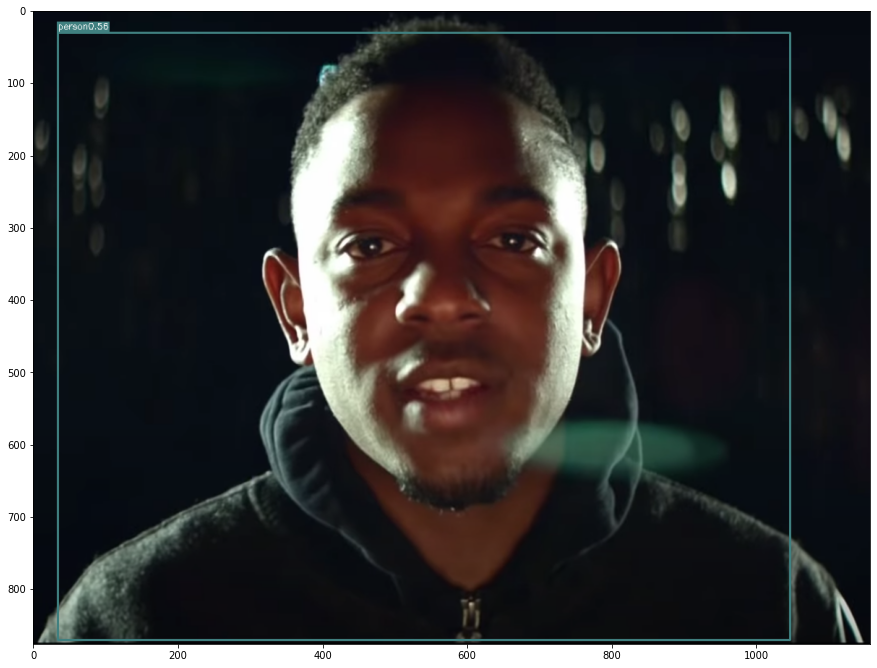

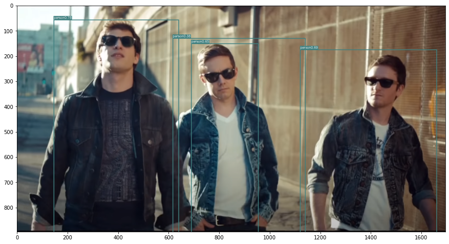

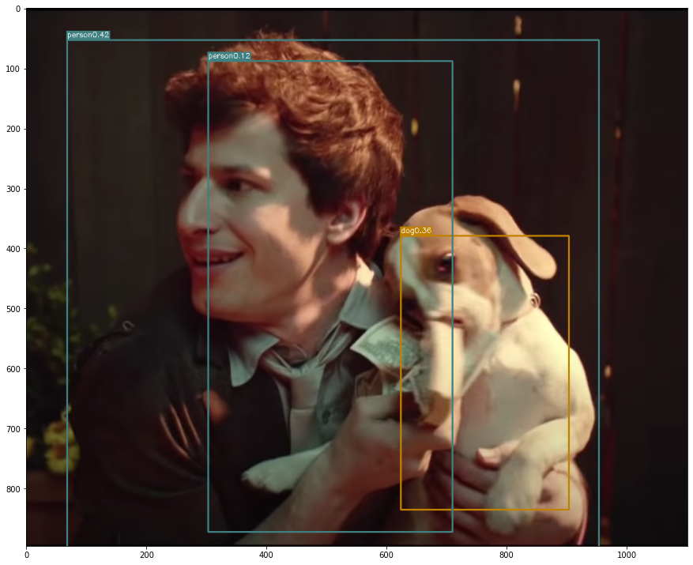

```python
def view_yolo_predictions(network):
    network.eval()

    predictions_folder = os.path.join(os.getcwd(), "predicted_images")
    os.makedirs(predictions_folder, exist_ok=True)

    # select random image from test set
    for yolo_name in ["yolo_1", "yolo_3", "yolo_dog"]:
      image_name = os.path.join("yolo_screenshot", yolo_name + ".png")
      image = cv2.imread(os.path.join(os.getcwd(), image_name))
      image = cv2.cvtColor(image, cv2.COLOR_BGR2RGB)

      print('predicting...')
      result = predict_image(network, image_name)
      for left_up, right_bottom, class_name, _, prob in result:
          color = COLORS[VOC_CLASSES.index(class_name)]
          cv2.rectangle(image, left_up, right_bottom, color, 2)
          label = class_name + str(round(prob, 2))
          text_size, baseline = cv2.getTextSize(label, cv2.FONT_HERSHEY_SIMPLEX, 0.4, 1)
          p1 = (left_up[0], left_up[1] - text_size[1])
          cv2.rectangle(image, (p1[0] - 2 // 2, p1[1] - 2 - baseline), (p1[0] + text_size[0], p1[1] + text_size[1]),
                        color, -1)
          cv2.putText(image, label, (p1[0], p1[1] + baseline), cv2.FONT_HERSHEY_SIMPLEX, 0.4, (255, 255, 255), 1, 8)

      plt.figure(figsize = (15,15))
      plt.imshow(image)
      plt.savefig(os.path.join(predictions_folder, "prediction_for_{}.pdf".format(yolo_name)))

view_yolo_predictions(net)
```